# グラフのゼータ関数

ryamada

2018年6月24日

## ゼータ関数と言えばリーマンのゼータ関数

$$\zeta_R(s) = \sum_{i=1}^\infty \frac{1}{i^s} =\sum_{z \in Z} \frac{1}{z^s}= \prod_{p \in P}\frac{1}{ (1-p^{-s})}$$

- リーマンのゼータ関数は、複素数 $s$の関数である
- 自然数全体$Z$に関する、$s$で定まる関数$\frac{1}{z}$総和である
- 素数全体$P$に関する、$s$で定まる関数$\frac{1}{(1-p^{-s})}$の総積である
- ただし、すべての自然数は、素数の積で表される。また、素数の重複あり組みあわせのすべてに対応する自然数が存在する

以下の展開に注意すると、$\prod_{p \in P}\frac{1}{ (1-p^{-s})}$の中に、すべての自然数の$-s$乗の和が含まれることが示せる。
$$\frac{1}{1-p^{-s}} = \sum_{i=1}^\infty (p^{-s})^i$$

### Rでいじってみよう

```r
my.zeta.riemann1 <- function(n,s){
  sum(1/((1:n)^s))
}
library(primes) # 素数を扱うパッケージ
my.zeta.riemann2 <- function(n,s){
  p <- generate_primes(max =n)
  prod((1/(1-p^(-s))))
}
```

```r
maxn <- 50
s <- 2.4 # 収束確認のために実数で試してみる

val1 <- val2 <- rep(0,maxn)
for(i in 1:maxn){
  val1[i] <- my.zeta.riemann1(i,s)
  val2[i] <- my.zeta.riemann2(i,s)
}
```

```r
library(pracma) # Riemann's zeta関数を実装しているパッケージ
```

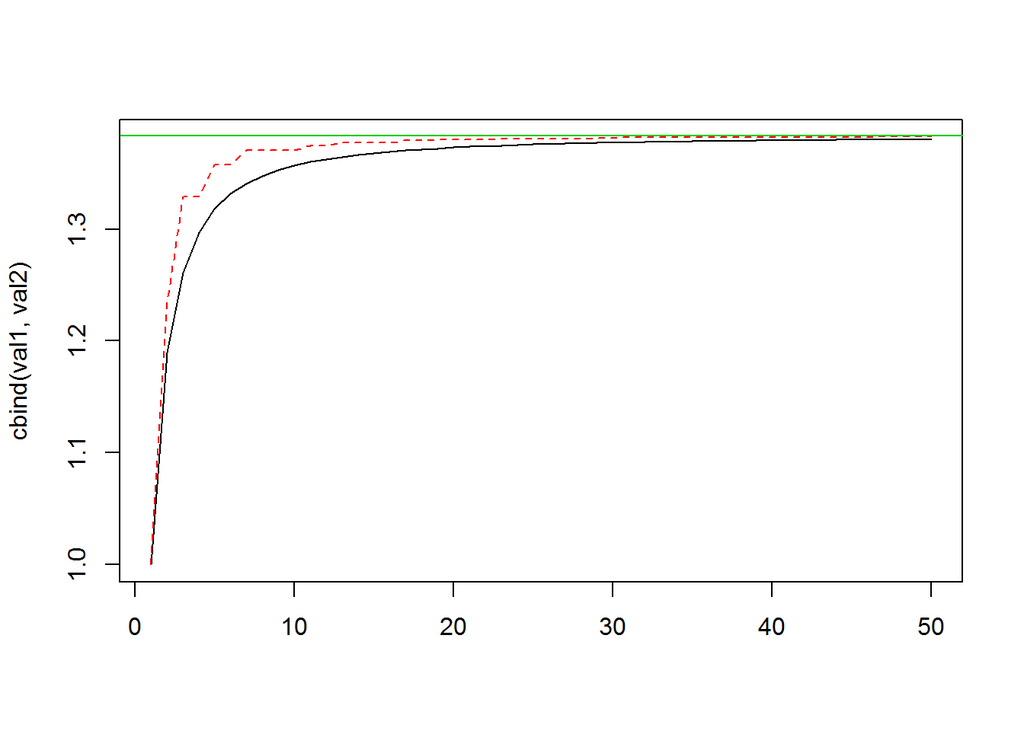

```r
true.val <- zeta(s) # ゼータ関数の値の「正解」
matplot(cbind(val1,val2),type="l")
abline(h=true.val,col=3)
```

### リーマンのゼータ関数の図示

リーマンのゼータ関数は複素関数である。

“https://ja.wikipedia.org/wiki/%E3%83%AA%E3%83%BC%E3%83%9E%E3%83%B3%E3%82%BC%E3%83%BC%E3%82%BF%E9%96%A2%E6%95%B0” 参照

```r
maxv <- 4
b <- 0.01
re <- seq(from=-maxv,to=maxv,by=b)
im <- seq(from=-maxv,to=maxv,by=b)
len <- length(re)
ri <- expand.grid(re,im)
s <- ri[,1] + 1i * ri[,2]
z <- zeta(s)
```

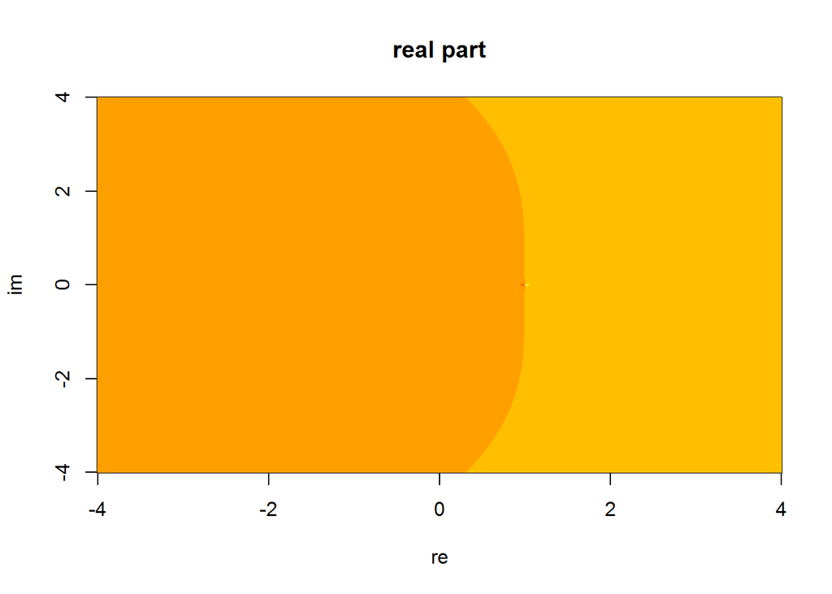

```r
# 実部の様子
image(re,im,matrix(Re(z),len,len),main="real part")
```

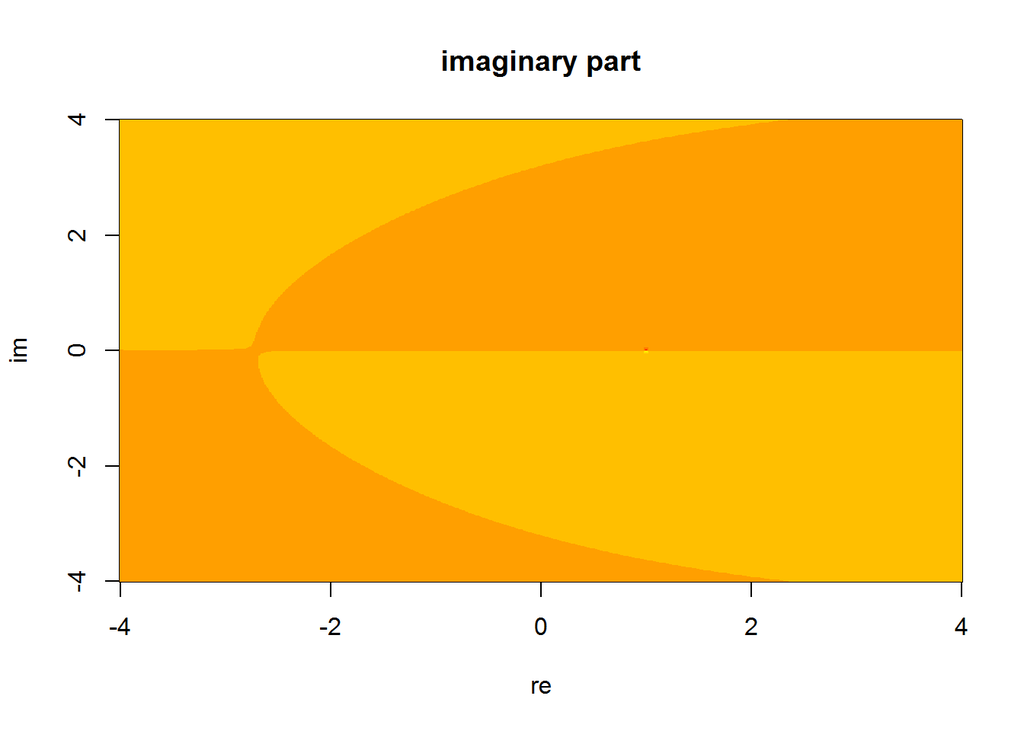

```r
# 虚部の様子
image(re,im,matrix(Im(z),len,len),main="imaginary part")
```

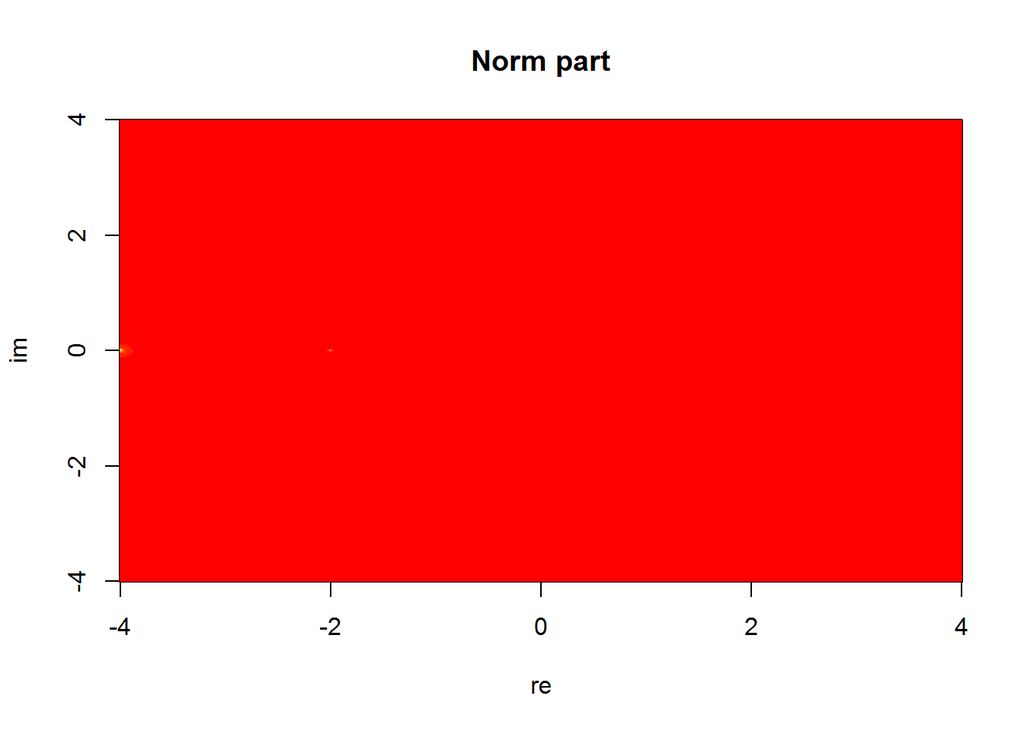

```r
# log(長さ)の様子
image(re,im,matrix(1/(Mod(z)),len,len),main="Norm part")
```

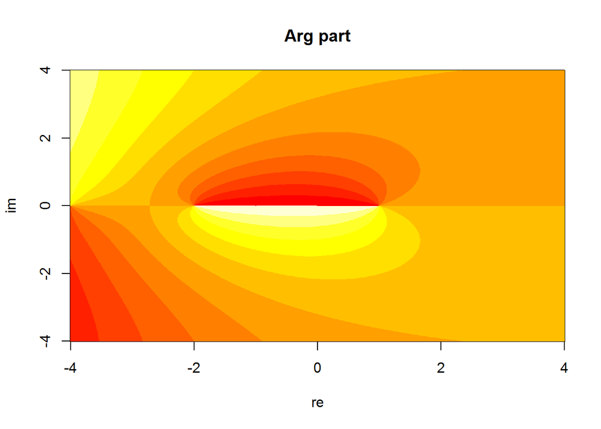

```r
# 角度の様子
image(re,im,matrix(Arg(z),len,len),main="Arg part")
```

## ゼータ関数は色々ある

リーマンのゼータ関数は、次のような関数であると言える

*「自然数全体」を把握するために、その構成要素である「素数全体」を使って表す* 「全体」はとても複雑なので、その複雑さを「関数」に押し込ん表す * 関数は、$(s,f(s))$という値の組をたくさん持っているので、複雑な状態を持つことができる

リーマンのゼータ関数を用いて、素数に関する情報が得られたりするわけであるが、それとは別に、上記の性質を「自然数」以外に見出すことで、様々なゼータ関数が定義されている。

グラフのゼータ関数もその一つである。

## グラフのゼータ関数

### 対象とするグラフ

ここで考えるグラフは

- ノード数が有限
- 連結
- 次数1のノードはない(行き止まりになるノードがない)
- ランクが1以上(ランクとは、グラフに(最大)全域木を取ったとき、最小全域木に入っていない辺の数)

とする

### グラフにおける「自然数」と「素数」

#### 「素数」

- グラフ上のある点から出発して戻ってくるパスをグラフが持つ「数」とする

ただし、ぐるりと回って戻ってくるパスにいくつかの条件を付ける。

- Closed: 出発ノードと終着ノードは同じであるとする
- Backtrackless: あるエッジを辿って、すぐさまそのエッジを逆向きに辿ってはいけない
- Tailless: 戻って来るときに、最後のエッジが最初のエッジの逆向きエッジではいけない(出発点・到着点のところは、ふくらみを持たないといけない)
- Primitive: 上記の条件を満足する周回パスを、複数回、回ってできるパスも上記の条件を満足してしまうが、複数周回のものは除き、単回周回のものを指してprimitiveと言う

これをClosed backtrackless tailess primitive paths (CBTPP) と呼ぶ。

今、あるCBTPPがあったとき、その始点終点をCBTPP上の別点に置き換えたものも、同じCBTPPとみなす(Equivalence class)ことにする。

このように、CBTPPでequivalence classesによって集約したclassesをグラフの「素数」とする。

#### 「素数」の表現方法

無向グラフXにn本のエッジがあるとする。それらを$E=\{\epsilon_1,...,\epsilon_n\}$とする。

このエッジに向きを考慮し、2倍の本数の向きのあるエッジの集合$E'=\{e_1,...,e_n,e_1^{-1},...,e_n^{-1}\}$を考える。

パスCを

$$C = a_1 a_2 ,,, a_s; a_i \in E'$$
ただし、$a_1$の始点と$a_n$の終点は同じノード(Closed)、 $a_{n+1} \ne a_n^{-1}$ (backtrackless)、$a_s \ne a_i$ (Tailless)、$C \ne D^m$ (primitive)である。

また、equivalent classとは$[C] = \{a_1a_2...a_s,a_2a_3...a_sa_1,...,a_s a_1...a_{s-1}\}$と同一視する、ということである。

この$[C]$が「素数」。

ちなみに、

$$a_1 a_2 a_3 a_4 a_5 a_6 a_7 a_8 a_9; a_7 = a_3^{-1}$$
というようなパスも素数に対応する。途中で同じエッジを異なる向きに1回ずつ通るような周回パスである。

#### 「自然数」

自然数は素数の積であるから、グラフの「自然数」はグラフの「素数」の積。

同じ$[C]$の複数回の周回パスは$[C]^m; m \ge 2$という「素数ではない自然数」。

$[C_1]\times [C_2]$という２つのグラフ素数の積が表すのは、２つの周回パスの順序によらないペアであって、これも「素数ではない自然数」。

## グラフの周回パスという「自然数」の集合

グラフ上に周回パスが無限に存在する。それが「自然数」として表される周回パスequivalence全体。

それらは、「素数」に相当する周回パスequivalenceの積であって、「周回パス全体(自然数)」に関するある情報が、「素数」によって表せる、というのが、グラフのゼータ関数の意味するところである。

## グラフのゼータ関数

グラフの「素数」の集合を$[P]$と書く。

Closed backtracless tailless primitive pathsのequivalence classesのことである。

今、この$p \in [P]$には長さがある。それを$\nu(p)$と書くことにする。

このとき以下をグラフのゼータ関数と言う。

$$\zeta_G(s) = \prod_{p \in [P]}\frac{1}{(1-s^{\nu(p)})}$$

グラフ$G$上に取れる、すべての周回パスに関する情報をもった関数で、$[P]$の要素の長さを用いた複素多項式の逆数となっている。

## グラフのゼータ関数の線形代数的表現３種

グラフ$G$は、頂点の集合とエッジの集合と、エッジの長さ情報とで決まっている。

その情報を使うと、$\zeta_G(s)$が正方行列の行列式の計算を介して計算できることが知られており、３通りの方法がある。

１つは、ノードペアの行列を基本としたもの(vertex zeta function)、２つ目はエッジペアの行列を基本としたもの(edge zeta function)、3つ目はグラフに全域木を取り全域木に含まれないエッジのペアの行列を基本としたもの(path zeta function)である。

$$\zeta_G(s)^{-1} = (1-s)^{r}\det{(I-A u + Q u^2)} = \det{(I-W_E)} = \det(I-Z_P)$$